## Practical mechine learning week4 project

### Background

Six young health participants were asked to perform one set of 10 repetitions of the Unilateral Dumbbell Biceps Curl in five different fashions: * Exactly according to the specification (Class A) * Throwing the elbows to the front (Class B) - mistake * Lifting the dumbbell only halfway (Class C) - mistake * Lowering the dumbbell only halfway (Class D) - mistake * Throwing the hips to the front (Class E) - mistake

Accelerometers were located on 1. belt 2. forearm 3. arm

### Task

reate a report describing: *how you built your model* how you used cross validation *what you think the expected out of sample error is* and why you made the choices you did

### QUESTION

Create a model to predict the manner in which the subjects did the exercise using the accelerometer data as predictors. The outcome to be predicted is the “classe” variable.

### Setup

```r
library(dplyr)
```

```r
library(ggplot2)
library(lubridate)
library(caret)
library(randomForest)
library(e1071)
library(rattle)
```

### Download source data

```r
setwd("C:/Users/Bruker/Desktop/datascience/practical_mech_learning/project")
url_training <- "C:/Users/Bruker/Desktop/datascience/practical_mech_learning/project/pml-training.csv"
url_testing <- "C:/Users/Bruker/Desktop/datascience/practical_mech_learning/project/pml-testing.csv"
training <- read.csv(url_training,na.strings = c("NA","#DIV/0!",""))
dim(training)
```

```
## [1] 19622   160
```

```r
testing <- read.csv(url_testing,na.strings = c("NA","#DIV/0!",""))
dim(testing)
```

```
## [1]  20 160
```

### Data Cleaning

```r
training <- training[,colSums(is.na(training))==0]
dim(training)
```

```
## [1] 19622    60
```

```r
testing <- testing[,colSums(is.na(testing))==0]
dim(testing)
```

```
## [1] 20 60
```

### Data Transformation : Convert date and add new variable (Day)

```r
training$cvtd_timestamp <- as.Date(training$cvtd_timestamp,format="%d/%m/%Y %H:%M")
training$Day <- as.factor(weekdays(training$cvtd_timestamp))
```

### exploratory data analysis

```r
table(training$classe)
```

```
##
##    A    B    C    D    E
## 5580 3797 3422 3216 3607
```

```r
prop.table(table(training$classe))
```

```
##
##         A         B         C         D         E
## 0.2843747 0.1935073 0.1743961 0.1638977 0.1838243
```

```r
prop.table(table(training$user_name))
```

```
##
##    adelmo  carlitos   charles    eurico    jeremy     pedro
## 0.1983488 0.1585975 0.1802059 0.1564570 0.1733768 0.1330140
```

```r
prop.table(table(training$user_name,training$classe),1)
```

```
##
##                    A         B         C         D         E
##   adelmo   0.2993320 0.1993834 0.1927030 0.1323227 0.1762590
##   carlitos 0.2679949 0.2217224 0.1584190 0.1561697 0.1956941
##   charles  0.2542421 0.2106900 0.1524321 0.1815611 0.2010747
##   eurico   0.2817590 0.1928339 0.1592834 0.1895765 0.1765472
##   jeremy   0.3459730 0.1437390 0.1916520 0.1534392 0.1651969
##   pedro    0.2452107 0.1934866 0.1911877 0.1796935 0.1904215
```

```r
prop.table(table(training$user_name,training$classe),2)
```

```
##
##                    A         B         C         D         E
##   adelmo   0.2087814 0.2043719 0.2191701 0.1601368 0.1901857
##   carlitos 0.1494624 0.1817224 0.1440678 0.1511194 0.1688384
##   charles  0.1611111 0.1962075 0.1575102 0.1996269 0.1971167
##   eurico   0.1550179 0.1559126 0.1428989 0.1809701 0.1502634
##   jeremy   0.2109319 0.1287859 0.1905319 0.1623134 0.1558082
##   pedro    0.1146953 0.1329997 0.1458212 0.1458333 0.1377876
```

```r
prop.table(table(training$classe,training$Day),1)
```

```
##
##        Friday    Monday Wednesday
##   A 0.3698925 0.4191756 0.2109319
##   B 0.4005794 0.4706347 0.1287859
##   C 0.3766803 0.4327878 0.1905319
##   D 0.3597637 0.4779229 0.1623134
##   E 0.3873025 0.4568894 0.1558082
```

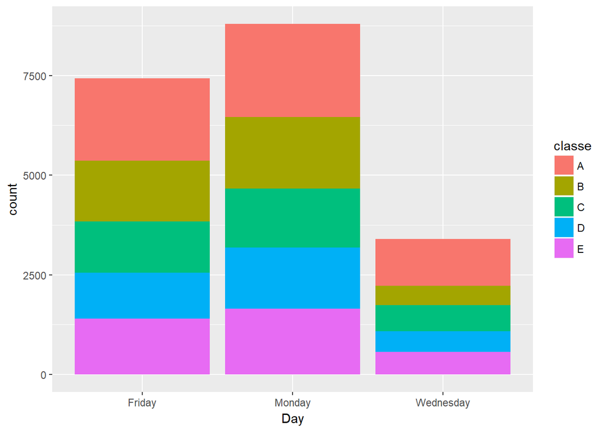

```r
qplot(x=Day,fill=classe,data=training)
```

## Reduce the number of variables

Remove the non-predictors from the training set. This includes the index, subject name, time and window variables.

```r
classe<- training$classe
trainRemove<- grepl("^X|timestamp|window", names(training))
training<- training[, !trainRemove]
training<- training[, sapply(training, is.numeric)]
training$classe<- classe
testRemove<- grepl("^X|timestamp|window", names(testing))
testing<- testing[, !testRemove]
testing<- testing[, sapply(testing, is.numeric)]
dim(training)
```

```
## [1] 19622    53
```

```r
dim(testing)
```

```
## [1] 20 53
```

## ALGORITHM

Partition the training data into a training set and a testing/validation set

```r
inTrain <- createDataPartition(training$classe,p=0.6,list = FALSE)
inTraining <- training[inTrain,]
inTesting <- training[-inTrain,]
```

## Model Analysis

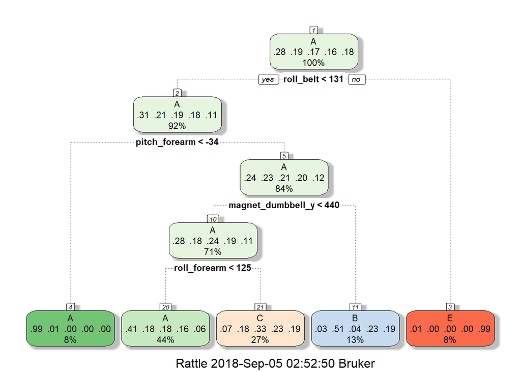

```r
model1 <- train(classe~.,data = inTraining,method="rpart")
fancyRpartPlot(model1$finalModel)
```

```r
prediction1 <- predict(model1,newdata = inTesting)
confusionMatrix(prediction1,inTesting$classe)
```

```
## Confusion Matrix and Statistics
##
##           Reference
## Prediction    A    B    C    D    E
##          A 2030  645  645  606  191
##          B   35  525   51  216  204
##          C  163  348  672  464  366
##          D    0    0    0    0    0
##          E    4    0    0    0  681
##
## Overall Statistics
##
##                Accuracy : 0.4981
##                  95% CI : (0.487, 0.5092)
##     No Information Rate : 0.2845
##     P-Value [Acc > NIR] : < 2.2e-16
##
##                   Kappa : 0.3435
##  Mcnemar's Test P-Value : NA
##
## Statistics by Class:
##
##                      Class: A Class: B Class: C Class: D Class: E
## Sensitivity            0.9095  0.34585  0.49123   0.0000  0.47226
## Specificity            0.6283  0.92004  0.79299   1.0000  0.99938
## Pos Pred Value         0.4931  0.50921  0.33383      NaN  0.99416
## Neg Pred Value         0.9458  0.85429  0.88068   0.8361  0.89373
## Prevalence             0.2845  0.19347  0.17436   0.1639  0.18379
## Detection Rate         0.2587  0.06691  0.08565   0.0000  0.08680
## Detection Prevalence   0.5247  0.13140  0.25656   0.0000  0.08731
## Balanced Accuracy      0.7689  0.63294  0.64211   0.5000  0.73582
```

this model’s confusionMatrix proves accuracy is rather low. So, let’s try it again with, this time with scaling and cross validation.

```r
model2 <- train(classe~.,data=inTraining,preProcess=c("center", "scale"), trControl = trainControl(method = "cv", number = 4),method="rpart")
prediction2 <- predict(model2,newdata = inTesting)
confusionMatrix(prediction2,inTesting$classe)
```

```
## Confusion Matrix and Statistics
##
##           Reference
## Prediction    A    B    C    D    E
##          A 2031  645  645  606  191
##          B   35  525   51  216  204
##          C  162  348  672  464  366
##          D    0    0    0    0    0
##          E    4    0    0    0  681
##
## Overall Statistics
##
##                Accuracy : 0.4982
##                  95% CI : (0.4871, 0.5093)
##     No Information Rate : 0.2845
##     P-Value [Acc > NIR] : < 2.2e-16
##
##                   Kappa : 0.3437
##  Mcnemar's Test P-Value : NA
##
## Statistics by Class:
##
##                      Class: A Class: B Class: C Class: D Class: E
## Sensitivity            0.9099  0.34585  0.49123   0.0000  0.47226
## Specificity            0.6283  0.92004  0.79315   1.0000  0.99938
## Pos Pred Value         0.4932  0.50921  0.33400      NaN  0.99416
## Neg Pred Value         0.9461  0.85429  0.88070   0.8361  0.89373
## Prevalence             0.2845  0.19347  0.17436   0.1639  0.18379
## Detection Rate         0.2589  0.06691  0.08565   0.0000  0.08680
## Detection Prevalence   0.5249  0.13140  0.25644   0.0000  0.08731
## Balanced Accuracy      0.7691  0.63294  0.64219   0.5000  0.73582
```

There was little to no improvement with scaling and cross validation using Decision Trees. For the next model I decided to then use Random Forest, which should provide better accuracy. # construct model using random forest

```r
model <- train(classe~.,data=inTraining,method="rf",metric="Accuracy",preProcess=c("center","scale"),trControl=trainControl(method = "cv",number = 4,p=0.60,allowParallel = TRUE))
print(model,digits=4)
```

```
## Random Forest
##
## 11776 samples
##    52 predictor
##     5 classes: 'A', 'B', 'C', 'D', 'E'
##
## Pre-processing: centered (52), scaled (52)
## Resampling: Cross-Validated (4 fold)
## Summary of sample sizes: 8831, 8832, 8832, 8833
## Resampling results across tuning parameters:
##
##   mtry  Accuracy  Kappa
##    2    0.9880    0.9849
##   27    0.9879    0.9847
##   52    0.9809    0.9758
##
## Accuracy was used to select the optimal model using the largest value.
## The final value used for the model was mtry = 2.
```

```r
predTest <- predict(model,inTesting)
```

## EVALUATION

### Test

Check the accuracy of the model by comparing the predictions to the actual results

```r
confusionMatrix(predTest, inTesting$classe)
```

```
## Confusion Matrix and Statistics
##
##           Reference
## Prediction    A    B    C    D    E
##          A 2227    4    0    0    0
##          B    5 1508   19    0    0
##          C    0    6 1349   18    1
##          D    0    0    0 1267    1
##          E    0    0    0    1 1440
##
## Overall Statistics
##
##                Accuracy : 0.993
##                  95% CI : (0.9909, 0.9947)
##     No Information Rate : 0.2845
##     P-Value [Acc > NIR] : < 2.2e-16
##
##                   Kappa : 0.9911
##  Mcnemar's Test P-Value : NA
##
## Statistics by Class:
##
##                      Class: A Class: B Class: C Class: D Class: E
## Sensitivity            0.9978   0.9934   0.9861   0.9852   0.9986
## Specificity            0.9993   0.9962   0.9961   0.9998   0.9998
## Pos Pred Value         0.9982   0.9843   0.9818   0.9992   0.9993
## Neg Pred Value         0.9991   0.9984   0.9971   0.9971   0.9997
## Prevalence             0.2845   0.1935   0.1744   0.1639   0.1838
## Detection Rate         0.2838   0.1922   0.1719   0.1615   0.1835
## Detection Prevalence   0.2843   0.1953   0.1751   0.1616   0.1837
## Balanced Accuracy      0.9985   0.9948   0.9911   0.9925   0.9992
```

## Final Model data and important predictors in the model

```r
model$finalModel
```

```
##
## Call:
##  randomForest(x = x, y = y, mtry = param$mtry)
##                Type of random forest: classification
##                      Number of trees: 500
## No. of variables tried at each split: 2
##
##         OOB estimate of  error rate: 0.86%
## Confusion matrix:
##      A    B    C    D    E  class.error
## A 3347    1    0    0    0 0.0002986858
## B   20 2247   12    0    0 0.0140412462
## C    0   20 2028    6    0 0.0126582278
## D    0    0   33 1896    1 0.0176165803
## E    0    0    0    8 2157 0.0036951501
```

```r
varImp(model)
```

```
## rf variable importance
##
##   only 20 most important variables shown (out of 52)
##
##                   Overall
## roll_belt          100.00
## yaw_belt            81.81
## magnet_dumbbell_z   70.25
## pitch_forearm       65.36
## magnet_dumbbell_y   61.66
## pitch_belt          61.50
## magnet_dumbbell_x   55.37
## roll_forearm        50.65
## accel_belt_z        45.52
## magnet_belt_z       44.07
## accel_dumbbell_y    43.68
## roll_dumbbell       43.35
## magnet_belt_y       41.87
## accel_dumbbell_z    36.79
## roll_arm            34.77
## accel_forearm_x     33.57
## accel_dumbbell_x    31.37
## gyros_belt_z        30.74
## yaw_dumbbell        29.20
## gyros_dumbbell_y    28.79
```

## Validation/Quiz

The accuracy of the model by predicting with the Validation/Quiz set supplied in the test file.

```r
print(predict(model, newdata=testing))
```

```
##  [1] B A B A A E D B A A B C B A E E A B B B
## Levels: A B C D E
```